# Linear Regression

Yuanting Lu

11/16/2020

### Linear Model

We are often interested in trying to determine the relationship between a pair of numerical variables. For example,

- Advertising spendings and the product sales.
- Hours of study and the test scores.

**Example 1.** Is there a relation between one’s credit ratings and one’s credit cards limit?

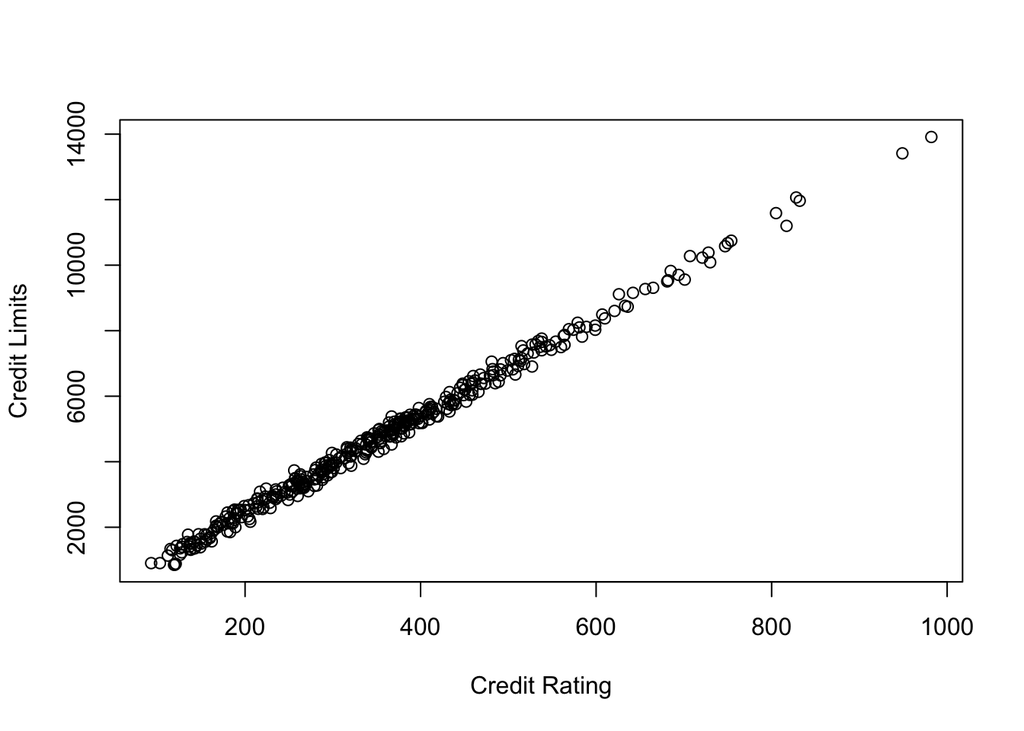

```r
a <- read.csv("https://albums.yuanting.lu/sta126/Credit.csv")
plot(a$Limit ~ a$Rating, xlab = "Credit Rating", ylab = "Credit Limits")
```

**Example 2.** Is there a relation between one’s credit ratings and one’s income?

**Example 3.** Is there a relation between one’s credit ratings and one’s age?

### Linear Correlation Coefficient

$$r = \dfrac{1}{n-1}\sum \left(\dfrac{x_i - \bar x}{s_x}\right)\left(\dfrac{y_i - \bar y}{s_y}\right)$$

Given the raw data in $x$ and $y$, the $R$ command for the linear correlation coefficient is

```r
cor(x, y)
```

Properties of the linear correlation coefficient $r$:

- $-1\le r \le 1$.
- When $r$ is close to $1$, there is strong positive linear correlation.
- When $r$ is close to $-1$, there is strong negative linear correlation.
- When $r$ is close to 0, there is little to no linear correlation.

**Example 4.** Find the linear correlation coefficient in the first three examples. Which pair has the strongest linear correlation?

### Regression Line

$$y = \alpha + \beta x$$

Given the raw data $x$ and $y$, the linear regression line can be found by the $R$ command

```r
lm(y ~ x)
```

**Example 5.** Find the linear regression lines between credit limits and credit ratings. What is the expected limit for someone whoes credit rating is 900?

```r
lm(a$Limit ~ a$Rating)
```

```
##
## Call:
## lm(formula = a$Limit ~ a$Rating)
##
## Coefficients:
## (Intercept)     a$Rating
##     -542.93        14.87
```